# Example: Parkinson’s disease

### Further results

For comparison with Dias et al. (2011), we can produce relative effects against placebo using the `relative_effects()` function with `trt_ref = 1`:

```r
(mix_releff_FE <- relative_effects(mix_fit_FE, trt_ref = 1))
```

```
#>       mean   sd  2.5%   25%   50%   75% 97.5% Bulk_ESS Tail_ESS Rhat
#> d[4] -0.54 0.48 -1.46 -0.87 -0.56 -0.21  0.43     1439     2275    1
#> d[2] -1.82 0.33 -2.46 -2.04 -1.82 -1.59 -1.14     5602     3215    1
#> d[3] -0.49 0.48 -1.43 -0.82 -0.49 -0.16  0.46     2255     2644    1
#> d[5] -0.84 0.52 -1.86 -1.21 -0.85 -0.49  0.17     1559     2448    1
```

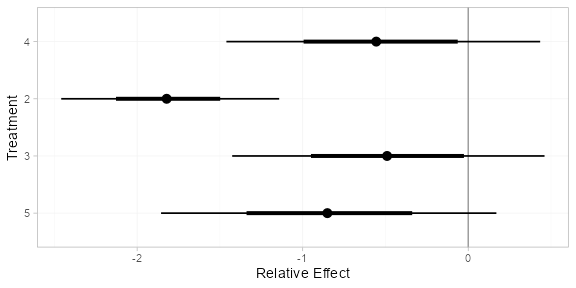

```r
plot(mix_releff_FE, ref_line = 0)
```

```r
(mix_releff_RE <- relative_effects(mix_fit_RE, trt_ref = 1))
```

```
#>       mean   sd  2.5%   25%   50%   75% 97.5% Bulk_ESS Tail_ESS Rhat
#> d[4] -0.52 0.62 -1.73 -0.90 -0.52 -0.14  0.68     1690     1682    1
#> d[2] -1.84 0.50 -2.86 -2.12 -1.83 -1.55 -0.86     4089     2312    1
#> d[3] -0.51 0.62 -1.72 -0.89 -0.50 -0.12  0.70     2941     2065    1
#> d[5] -0.80 0.76 -2.31 -1.24 -0.79 -0.38  0.70     1791     1643    1
```

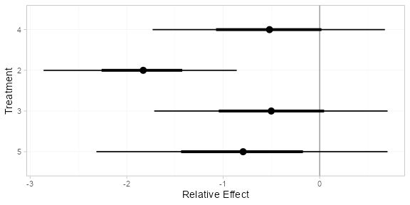

```r
plot(mix_releff_RE, ref_line = 0)
```

Following Dias et al. (2011), we produce absolute predictions of the mean off-time reduction on each treatment assuming a Normal distribution for the outcomes on treatment 1 (placebo) with mean $-0.73$ and precision $21$. We use the `predict()` method, where the `baseline` argument takes a `distr()` distribution object with which we specify the corresponding Normal distribution, and we specify `trt_ref = 1` to indicate that the baseline distribution corresponds to treatment 1. (Strictly speaking, `type = "response"` is unnecessary here, since the identity link function was used.)

```r
mix_pred_FE <- predict(mix_fit_FE,
                       baseline = distr(qnorm, mean = -0.73, sd = 21^-0.5),
                       type = "response",
                       trt_ref = 1)
mix_pred_FE
```

```
#>          mean   sd  2.5%   25%   50%   75% 97.5% Bulk_ESS Tail_ESS Rhat
#> pred[4] -1.26 0.54 -2.28 -1.63 -1.27 -0.89 -0.21     1564     2770    1
#> pred[1] -0.72 0.22 -1.14 -0.87 -0.72 -0.58 -0.29     3556     3638    1
#> pred[2] -2.54 0.40 -3.33 -2.81 -2.53 -2.27 -1.77     5100     3406    1
#> pred[3] -1.21 0.54 -2.28 -1.58 -1.21 -0.85 -0.13     2366     3038    1
#> pred[5] -1.57 0.57 -2.69 -1.95 -1.58 -1.17 -0.47     1656     2573    1
```

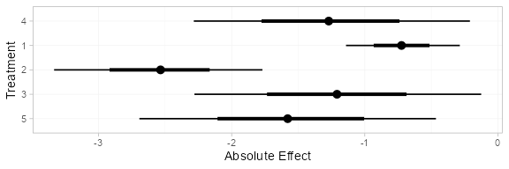

```r
plot(mix_pred_FE)
```

```r
mix_pred_RE <- predict(mix_fit_RE,
                       baseline = distr(qnorm, mean = -0.73, sd = 21^-0.5),
                       type = "response",
                       trt_ref = 1)
mix_pred_RE
```

```
#>          mean   sd  2.5%   25%   50%   75% 97.5% Bulk_ESS Tail_ESS Rhat
#> pred[4] -1.25 0.65 -2.51 -1.67 -1.24 -0.84  0.05     1799     1935    1
#> pred[1] -0.73 0.22 -1.17 -0.88 -0.73 -0.58 -0.31     4051     3817    1
#> pred[2] -2.57 0.54 -3.62 -2.89 -2.57 -2.24 -1.53     4082     2741    1
#> pred[3] -1.24 0.66 -2.52 -1.64 -1.24 -0.82  0.05     3016     2476    1
#> pred[5] -1.53 0.79 -3.07 -2.01 -1.53 -1.06  0.04     1830     1872    1
```

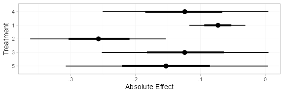

```r
plot(mix_pred_RE)
```

If the `baseline` argument is omitted, predictions of mean off-time reduction will be produced for every *arm-based* study in the network based on their estimated baseline response $\mu_j$:

```r
mix_pred_FE_studies <- predict(mix_fit_FE, type = "response")
mix_pred_FE_studies
```

```
#> ---------------------------------------------------------------------- Study: 1 ----
#>
#>             mean   sd  2.5%   25%   50%   75% 97.5% Bulk_ESS Tail_ESS Rhat
#> pred[1: 4] -1.66 0.46 -2.57 -1.97 -1.66 -1.35 -0.73     1773     2308    1
#> pred[1: 1] -1.12 0.43 -1.96 -1.42 -1.11 -0.82 -0.31     3431     2745    1
#> pred[1: 2] -2.94 0.51 -3.94 -3.28 -2.92 -2.60 -1.95     3163     2927    1
#> pred[1: 3] -1.61 0.39 -2.33 -1.87 -1.62 -1.34 -0.85     3321     2745    1
#> pred[1: 5] -1.96 0.50 -2.94 -2.31 -1.97 -1.63 -1.00     1872     2319    1
#>
#> ---------------------------------------------------------------------- Study: 2 ----
#>
#>             mean   sd  2.5%   25%   50%   75% 97.5% Bulk_ESS Tail_ESS Rhat
#> pred[2: 4] -1.17 0.51 -2.16 -1.53 -1.18 -0.83 -0.17     1429     2350    1
#> pred[2: 1] -0.64 0.26 -1.15 -0.81 -0.64 -0.46 -0.11     5027     3218    1
#> pred[2: 2] -2.45 0.24 -2.92 -2.62 -2.45 -2.28 -1.99     4600     3784    1
#> pred[2: 3] -1.12 0.52 -2.12 -1.48 -1.13 -0.77 -0.10     2135     2645    1
#> pred[2: 5] -1.48 0.55 -2.51 -1.85 -1.49 -1.11 -0.41     1540     2193    1
#>
#> ---------------------------------------------------------------------- Study: 3 ----
#>
#>             mean   sd  2.5%   25%   50%   75% 97.5% Bulk_ESS Tail_ESS Rhat
#> pred[3: 4] -1.12 0.42 -1.95 -1.40 -1.11 -0.84 -0.28     1776     2446    1
#> pred[3: 1] -0.58 0.36 -1.29 -0.82 -0.58 -0.34  0.12     4552     3294    1
#> pred[3: 2] -2.40 0.38 -3.17 -2.65 -2.40 -2.14 -1.65     4155     3226    1
#> pred[3: 3] -1.07 0.47 -2.00 -1.38 -1.07 -0.75 -0.13     2816     2808    1
#> pred[3: 5] -1.42 0.47 -2.36 -1.73 -1.42 -1.12 -0.52     2004     2545    1
```

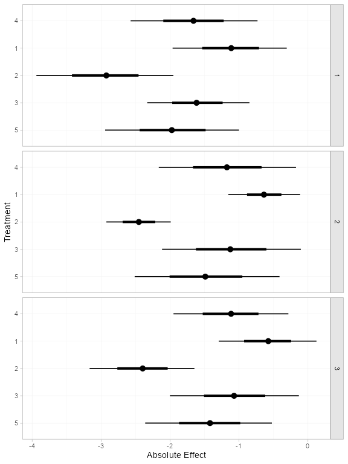

```r
plot(mix_pred_FE_studies)
```

We can also produce treatment rankings, rank probabilities, and cumulative rank probabilities.

```r
(mix_ranks <- posterior_ranks(mix_fit_FE))
```

```
#>         mean   sd 2.5% 25% 50% 75% 97.5% Bulk_ESS Tail_ESS Rhat
#> rank[4] 3.48 0.72    2   3   3   4     5     2118       NA    1
#> rank[1] 4.65 0.76    2   5   5   5     5     1863       NA    1
#> rank[2] 1.05 0.27    1   1   1   1     2     2313     2316    1
#> rank[3] 3.55 0.91    2   3   4   4     5     3138       NA    1
#> rank[5] 2.27 0.64    1   2   2   2     4     2398     2801    1
```

```r
plot(mix_ranks)
```

[output not shown]

```r
(mix_rankprobs <- posterior_rank_probs(mix_fit_FE))
```

```
#>      p_rank[1] p_rank[2] p_rank[3] p_rank[4] p_rank[5]
#> d[4]      0.00      0.05      0.50      0.37      0.08
#> d[1]      0.00      0.04      0.06      0.11      0.79
#> d[2]      0.96      0.03      0.01      0.00      0.00
#> d[3]      0.00      0.16      0.26      0.46      0.12
#> d[5]      0.04      0.73      0.17      0.05      0.01
```

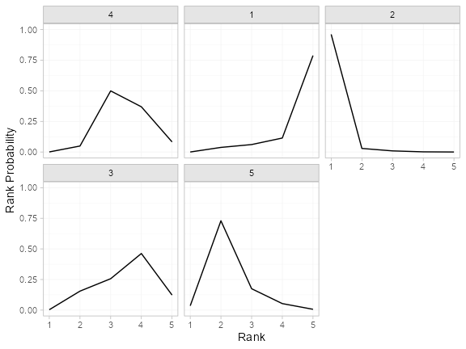

```r
plot(mix_rankprobs)
```

```r
(mix_cumrankprobs <- posterior_rank_probs(mix_fit_FE, cumulative = TRUE))
```

```
#>      p_rank[1] p_rank[2] p_rank[3] p_rank[4] p_rank[5]
#> d[4]      0.00      0.05      0.55      0.92         1
#> d[1]      0.00      0.04      0.10      0.21         1
#> d[2]      0.96      0.99      1.00      1.00         1
#> d[3]      0.00      0.16      0.41      0.88         1
#> d[5]      0.04      0.77      0.94      0.99         1
```

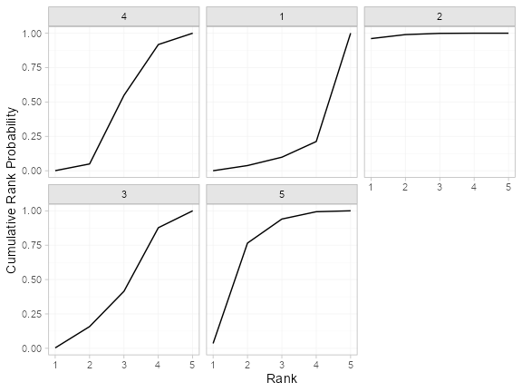

```r
plot(mix_cumrankprobs)
```

## References

Dias, S., N. J. Welton, A. J. Sutton, and A. E. Ades. 2011. “NICE DSU Technical Support Document 2: A Generalised Linear Modelling Framework for Pair-Wise and Network Meta-Analysis of Randomised Controlled Trials.” National Institute for Health and Care Excellence. https://www.sheffield.ac.uk/nice-dsu.